# ML_lab2

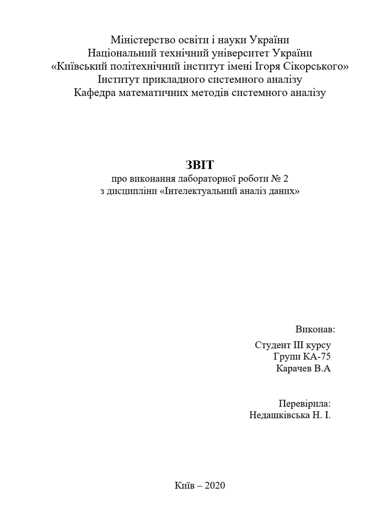

```python
import matplotlib.pyplot as plt
import seaborn as sns
import numpy as np
import sys
import warnings
warnings.simplefilter("ignore")
np.random.seed(0)
X=np.random.randn(300,2)
Y=np.logical_xor(X[:,0]>0, X[:,1]>0)
```

### 1)Представити початковi данi графiчно.

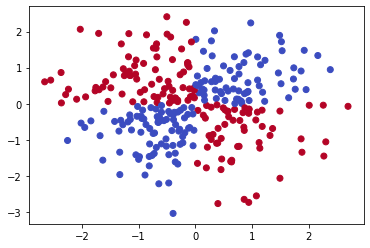

```python
plt.scatter(X[:,0], X[:,1], c=Y, cmap=plt.cm.coolwarm)
```

### 2. Розбити данi на навчальний i перевiрочний набори.

```python
from sklearn.model_selection import train_test_split
from sklearn.preprocessing import StandardScaler

X = StandardScaler().fit_transform(X)

Xtrain, Xtest, Ytrain, Ytest=train_test_split(X, Y)
```

### 3) Побудувати моделi класифiкацiї або регресiї згiдно з варiантом.

Побудувати моделi класифiкацiї на основi методу опорних векторiв:

• Моделi sklearn.svm.LinearSVC та SVC(kernel="linear") з лiнiйним ядром, встановити велике значенням параметра С. При використан- нi LinearSVC звернути увагу, що навчальнi данi мають бути попе- редньо масштабованi i центрованi.

• Моделi з лiнiйним ядром i меншими значеннями параметра С для даних, якi частково перетинаються.

• Моделi SVC(kernel="rbf") з ядром "гаусiвська радiальна базисна функцiя". Розглянути рiзнi комбiнацiї гiперпараметрiв gamma i C, такi як: gamma=0.1 i C=0.01; gamma=0.1 i C=1; gamma=0.1 i C=100; gamma=10 i C=0.01; gamma=10 i C=1; gamma=10 i C=100. Збiльшення gamma призводить до стиснення дзвоноподiбної кривої, в результатi вплив кожного прикладу зменшується; границя рiшень бiльше звивається навколо окремих прикладiв. Невелике значен- ня gamma робить границю рiшень бiльш гладкою. Гiперпараметр gamma дiє як регуляризатор: при перенавчаннi слiд зменшити зна- чення gamma.

• Побудувати границi рiшень графiчно для кожної з моделей.

• Вивести значення опорних векторiв (атрибут support*vectors*) для моделей.

• Настроїти гiперпараметри gamma i C за допомогою перехресної пе- ревiрки.

• Настроїти гiперпараметр probability за допомогою перехресної пе- ревiрки.

1) Лінійне ядро

```python
from sklearn.metrics import accuracy_score, classification_report
from sklearn.metrics import precision_recall_curve
from sklearn.metrics import plot_precision_recall_curve, roc_curve, plot_roc_curve, auc, confusion_matrix
```

```python
from sklearn.svm import LinearSVC

def linear_svc_class(Xtrain, Xtest, Ytrain, Ytest, c=100):
    model=LinearSVC(C=c)
    model.fit(Xtrain,Ytrain)
    print(model.coef_, '    ', model.intercept_)
    print("Accuracy: ", accuracy_score(Ytest, model.predict(Xtest)))
    return model
```

```python
def plot_curves(classifier, Xtest, Ytest):
    plot_precision_recall_curve(classifier, Xtest, Ytest)
    plot_roc_curve(classifier, Xtest, Ytest)
    fpr, tpr, thresholds = roc_curve(Ytest, classifier.predict(Xtest))
    print("Auc: ", auc(fpr, tpr))
```

```
[[-0.03645827  0.11624725]]      [0.03575221]
Accuracy:  0.5066666666666667
              precision    recall  f1-score   support

       False       0.57      0.33      0.41        40
        True       0.48      0.71      0.57        35

    accuracy                           0.51        75
   macro avg       0.52      0.52      0.49        75
weighted avg       0.53      0.51      0.49        75

Auc:  0.5196428571428572
```

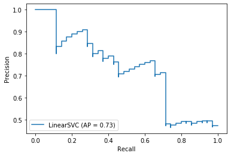

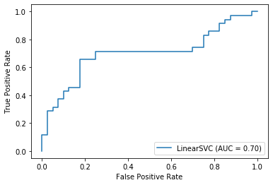

```python
classifier=linear_svc_class(Xtrain, Xtest, Ytrain, Ytest)
print(classification_report(Ytest, classifier.predict(Xtest)))
plot_curves(classifier, Xtest, Ytest)
```

```
[[-0.02135685  0.02451014]]      [-0.0392541]
Accuracy:  0.6533333333333333
              precision    recall  f1-score   support

       False       0.61      1.00      0.75        40
        True       1.00      0.26      0.41        35

    accuracy                           0.65        75
   macro avg       0.80      0.63      0.58        75
weighted avg       0.79      0.65      0.59        75

Auc:  0.6285714285714286
```

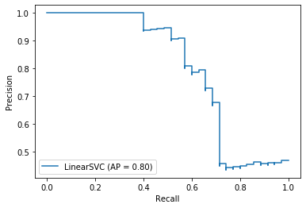

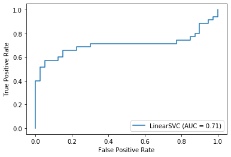

```python
classifier=linear_svc_class(Xtrain, Xtest, Ytrain, Ytest, 0.01)
#print("Support_vectros: "_.support_vectors_)
print(classification_report(Ytest, classifier.predict(Xtest)))
plot_curves(classifier, Xtest, Ytest)
```

```python
from sklearn.svm import SVC

def svc_class(Xtrain, Xtest, Ytrain, Ytest, c=100):
    model=SVC(C=c, kernel='linear')
    model.fit(Xtrain, Ytrain)
    print(model.coef_, '    ', model.intercept_)
    print("Accuracy: ", accuracy_score(Ytest, model.predict(Xtest)))
    return model
```

```
[[-0.00060728  0.00058721]]      [-0.99933315]
Accuracy:  0.5333333333333333
              precision    recall  f1-score   support

       False       0.53      1.00      0.70        40
        True       0.00      0.00      0.00        35

    accuracy                           0.53        75
   macro avg       0.27      0.50      0.35        75
weighted avg       0.28      0.53      0.37        75

Auc:  0.5
Support_vectros:  [[ 7.75514646e-01  2.83441825e-02]
 [ 1.01124452e+00  1.44372957e+00]
 [ 2.44213517e+00  9.73613260e-01]
 [-9.22576118e-01 -5.36771770e-02]
 [ 2.35824635e-02 -8.32704711e-02]
 [-6.27339166e-01 -7.92379301e-01]
 [ 2.27046769e-01  1.48587872e+00]
 [ 9.49353805e-02  1.81908326e+00]
 [ 1.93207865e+00  9.34992102e-01]
 [-5.95913065e-01 -1.19540814e+00]
 [-5.60750239e-01 -4.99160984e-01]
 [ 1.25983696e+00  3.43034137e-01]
 [ 4.35501128e-01  6.44432183e-01]
 [ 2.90589339e-01  1.00592872e+00]
 [ 4.19817579e-01  2.05539643e+00]
 [-2.65649607e-01 -1.35706193e+00]
 [-2.14682690e+00 -1.00290886e+00]
 [ 6.02820621e-01  1.13405763e-01]
 [ 1.00640291e+00  3.66168119e-01]
 [ 2.49434003e-01  6.62665031e-01]
 [ 4.32555478e-01  4.05629049e-01]
 [ 1.80477244e+00  1.02377015e+00]
 [ 1.81224900e-01  6.10334805e-01]
 [-1.23540151e+00 -1.32869127e+00]
 [-7.10245688e-01 -6.68337647e-01]
 [-1.53057769e+00 -1.55081312e+00]
 [ 1.79868692e+00  7.12374526e-01]
 [ 5.77890133e-01  1.07760765e+00]
```

[output cut: 174 more lines]

[output not shown]

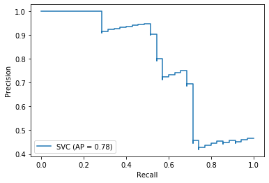

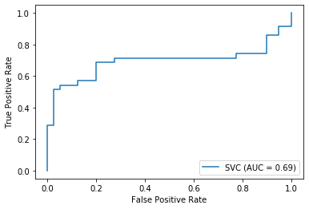

```python
classifier=svc_class(Xtrain, Xtest, Ytrain, Ytest, 100)

print(classification_report(Ytest, classifier.predict(Xtest)))
plot_curves(classifier, Xtest, Ytest)
print("Support_vectros: ", classifier.support_vectors_)
```

```
[[-0.00048921  0.00070596]]      [-0.99941137]
Accuracy:  0.5333333333333333
Auc:  0.5
Support_vectros:  [[ 7.75514646e-01  2.83441825e-02]
 [ 1.01124452e+00  1.44372957e+00]
 [ 2.44213517e+00  9.73613260e-01]
 [-9.22576118e-01 -5.36771770e-02]
 [ 2.35824635e-02 -8.32704711e-02]
 [-6.27339166e-01 -7.92379301e-01]
 [ 2.27046769e-01  1.48587872e+00]
 [ 9.49353805e-02  1.81908326e+00]
 [ 1.93207865e+00  9.34992102e-01]
 [-5.95913065e-01 -1.19540814e+00]
 [-5.60750239e-01 -4.99160984e-01]
 [ 1.25983696e+00  3.43034137e-01]
 [ 4.35501128e-01  6.44432183e-01]
 [ 2.90589339e-01  1.00592872e+00]
 [ 4.19817579e-01  2.05539643e+00]
 [-2.65649607e-01 -1.35706193e+00]
 [-2.14682690e+00 -1.00290886e+00]
 [ 6.02820621e-01  1.13405763e-01]
 [ 1.00640291e+00  3.66168119e-01]
 [ 2.49434003e-01  6.62665031e-01]
 [ 4.32555478e-01  4.05629049e-01]
 [ 1.80477244e+00  1.02377015e+00]
 [ 1.81224900e-01  6.10334805e-01]
 [-1.23540151e+00 -1.32869127e+00]
 [-7.10245688e-01 -6.68337647e-01]
 [-1.53057769e+00 -1.55081312e+00]
 [ 1.79868692e+00  7.12374526e-01]
 [ 5.77890133e-01  1.07760765e+00]
 [ 1.17303252e+00  1.32886969e+00]
 [-1.06039546e+00 -2.89251206e-01]
 [-3.23488526e-02 -6.58920641e-01]
 [-7.76910489e-01 -5.57100869e-01]
 [-1.35670424e-01 -8.92950740e-01]
 [-8.90393854e-01 -1.45441533e+00]
 [-9.52759997e-01 -1.40234706e+00]
 [ 6.22033214e-01  4.65726415e-01]
 [-2.98625041e-01 -2.79213277e-01]
```

[output cut: 166 more lines]

[output not shown]

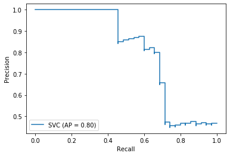

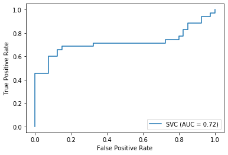

```python
classifier=svc_class(Xtrain, Xtest, Ytrain, Ytest, 0.01)

plot_curves(classifier, Xtest, Ytest)
print("Support_vectros: ",classifier.support_vectors_)
```

```python
def svc_rbf(Xtrain, Xtest, Ytrain, Ytest, gamma='scale', c=1):
    model=SVC(C=c, kernel='rbf', gamma=gamma)
    model.fit(Xtrain, Ytrain)
    print("Accuracy: ", accuracy_score(Ytest, model.predict(Xtest)))
    return model
```

```python
models=[]
for i in range(5):
    for j in range(3):
        print("gamma = ", 0.1*10**j, " C = ", 0.01*10**i)
        models.append(svc_rbf(Xtrain, Xtest, Ytrain, Ytest, 0.1*10**j, 0.01*10**i))
```

```
gamma =  0.1  C =  0.01
Accuracy:  0.5333333333333333
gamma =  1.0  C =  0.01
Accuracy:  0.5333333333333333
gamma =  10.0  C =  0.01
Accuracy:  0.5333333333333333
gamma =  0.1  C =  0.1
Accuracy:  0.56
gamma =  1.0  C =  0.1
Accuracy:  0.8933333333333333
gamma =  10.0  C =  0.1
Accuracy:  0.72
gamma =  0.1  C =  1.0
Accuracy:  0.7333333333333333
gamma =  1.0  C =  1.0
Accuracy:  1.0
gamma =  10.0  C =  1.0
Accuracy:  0.9733333333333334
gamma =  0.1  C =  10.0
Accuracy:  0.8933333333333333
gamma =  1.0  C =  10.0
Accuracy:  1.0
gamma =  10.0  C =  10.0
Accuracy:  0.9866666666666667
gamma =  0.1  C =  100.0
Accuracy:  0.9733333333333334
gamma =  1.0  C =  100.0
Accuracy:  1.0
gamma =  10.0  C =  100.0
Accuracy:  0.9866666666666667
```

```
support verctors: [[ 7.75514646e-01  2.83441825e-02]
 [-9.22576118e-01 -5.36771770e-02]
 [ 2.35824635e-02 -8.32704711e-02]
 [ 9.49353805e-02  1.81908326e+00]
 [ 4.56864279e-02 -1.14920131e+00]
 [ 6.02820621e-01  1.13405763e-01]
 [ 2.49434003e-01  6.62665031e-01]
 [ 1.81224900e-01  6.10334805e-01]
 [-3.23488526e-02 -6.58920641e-01]
 [ 2.37833687e-01  4.04550833e-01]
 [ 1.50351837e-01  3.28493270e-01]
 [-1.28487242e-02 -6.42139763e-01]
 [-2.21251442e-01 -2.10043477e-01]
 [ 2.46718517e-01  1.21343327e-01]
 [ 9.30833359e-02  5.54114095e-01]
 [-1.16172948e-01 -8.58604697e-02]
 [-6.89688036e-01 -8.63694450e-02]
 [-3.03632933e-01 -3.03635550e+00]
 [ 2.10099014e-01  4.28493188e-01]
 [ 8.05819537e-01  1.54163222e-01]
 [ 6.04827216e-02 -7.17053811e-01]
 [-1.74291515e-01 -1.58573279e-01]
 [ 1.02378689e+00  1.12530695e-01]
 [-2.80674654e-01 -2.15984656e-01]
 [-5.05371019e-01 -2.82671258e-02]
 [ 1.29628264e+00  8.97255360e-02]
 [ 8.90332628e-01  8.37662682e-02]
 [ 4.28287734e-02 -2.63722986e-01]
 [ 1.22764231e-01 -1.64019171e+00]
 [ 7.70880882e-01 -1.35792025e-01]
 [ 3.61470567e-01 -7.40712023e-02]
 [ 6.77100835e-02  4.05544845e-01]
 [ 5.72994705e-01 -9.21117891e-02]
 [ 2.24978779e-01 -2.96321483e-01]
 [ 5.66679717e-02  4.54963401e-01]
 [-5.68429709e-01  2.01226322e-01]
 [-2.25427173e+00  4.49877727e-02]
 [-2.23663382e-01  8.09926398e-02]
 [-5.82552946e-01  5.65398827e-02]
 [ 1.29815754e-01 -1.63536290e-01]
 [-1.30074971e-01  4.72107494e-01]
 [-2.96204275e-01  1.19364011e-01]
 [ 9.50988028e-01 -9.11104877e-02]
 [ 2.07423531e+00 -2.02566090e-02]
 [ 2.81710806e-01 -2.62938504e-02]
 [ 6.54955245e-01 -1.84753559e-01]
 [ 4.63175856e-01 -9.85327186e-03]
 [-4.61253947e-04  2.19789867e-01]
 [ 1.70382037e-02  1.74620388e+00]
 [-4.41636822e-02  1.18963720e-01]
 [-2.48072202e-02  1.04967344e+00]
 [ 2.60071335e-01 -3.79173725e-01]
 [-2.23004168e-01  1.22427367e-01]
 [ 6.45754449e-01 -1.99199599e-01]
 [ 3.93341478e-02  2.46131672e-01]]
Auc:  0.9714285714285714
```

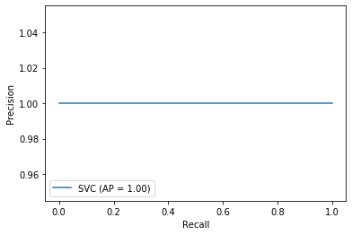

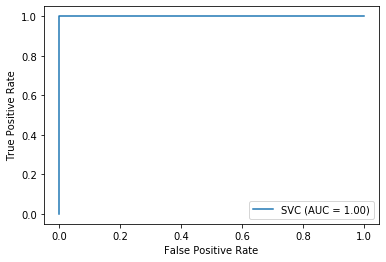

```python
print("support verctors:", models[12].support_vectors_)
plot_curves(models[12], Xtest, Ytest)
```

#### Границi рiшень графiчно для кожної з моделей:

```python
def draw_contour(model, X):
    h=0.01
    x_min=X[:,0].min()
    x_max=X[:,0].max()
    y_min=X[:,1].min()
    y_max=X[:,1].max()

    xx= np.meshgrid(np.arange(x_min, x_max, h),
                        np.arange(y_min,y_max, h))
    plt.scatter(X[:,0], X[:,1], c=Y, cmap=plt.cm.coolwarm)
    #plt.plot(svm_vectors[0])
    Z=model.predict(np.c_[xx[0].ravel(), xx[1].ravel()])
    Z=Z.reshape(xx[0].shape)
    plt.contourf(xx[0], xx[1], Z, cmap=plt.cm.coolwarm, alpha=0.8)
```

```
[[-0.02495988  0.02890976]]      [-0.04678633]
Accuracy:  0.6533333333333333
```

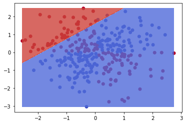

```python
#for f in (svm_class, svc_class, svc_rbf):
model=linear_svc_class(Xtrain, Xtest, Ytrain, Ytest, c=0.1)
draw_contour(model, X)
```

```
[[-0.00048921  0.00070596]]      [-0.99941137]
Accuracy:  0.5333333333333333
```

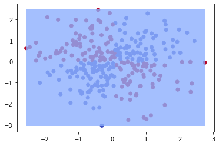

```python
model=svc_class(Xtrain, Xtest, Ytrain, Ytest, 0.01)
draw_contour(model, X)
```

Лінійні моделі показують низьку ефективність на тренувальних та тестових вибірках, тобто має місце недонавчання

```
Accuracy:  0.9866666666666667
```

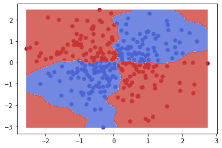

```python
model=svc_rbf(Xtrain, Xtest, Ytrain, Ytest, 10,10)
draw_contour(model, X)
```

```python
print("Train score:",  accuracy_score(Ytrain, model.predict(Xtrain)), " Test score: ",  accuracy_score(Ytest, model.predict(Xtest)))
```

```
Train score: 1.0  Test score:  0.9866666666666667
```

Очевидно, що при таких виоких значеннях перенавчання немає

#### Настроїти гiперпараметри gamma i C за допомогою перехресної перевiрки.

Для цієї цілі реалізуєм пошук по сітці з використанням перехресної перевірки

```python
from sklearn.model_selection import GridSearchCV
parameters = {'gamma':[0.01*10**i for i in range(5)], 'C':[0.1*10**i for i in range(5)]}
model = SVC(kernel='rbf')
gr_search=GridSearchCV(model, parameters, cv=20)
print("Best params:",gr_search.fit(Xtest, Ytest).best_params_)
print("Best score:",gr_search.fit(Xtest, Ytest).best_score_)
```

```
Best params: {'C': 100.0, 'gamma': 1.0}
Best score: 0.9875
```

#### Висновок:

Для XOR найкращій результат показує метод опорних векторів з гаусивським радіальним ядром

## Для цифр:

```python
from sklearn.datasets import load_digits
X=load_digits().data
Y=load_digits().target
Xtrain, Xtest, Ytrain, Ytest=train_test_split(X, Y)
```

##### Візуалізація за допомогою методу головних компонент:

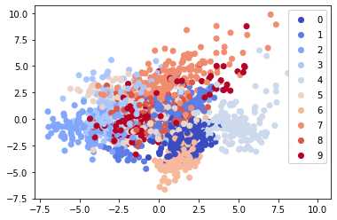

```python
from sklearn.decomposition import PCA
X=StandardScaler().fit_transform(X)

X_pca=PCA().fit_transform(X, 2)
fig, ax=plt.subplots()
scatter=ax.scatter(X_pca[:,0], X_pca[:,1], c=Y, cmap=plt.cm.coolwarm)
ax.add_artist(ax.legend(*scatter.legend_elements()))
#plt.scatter(X_pca[:,0], X_pca[:,1], c=Y, cmap=plt.cm.coolwarm, label=Y)
```

##### Візуалізація за допомогою tsne

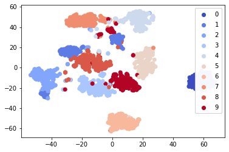

```python
from sklearn.manifold import TSNE
X_tsne=TSNE().fit_transform(X)
fig, ax=plt.subplots()
scatter=ax.scatter(X_tsne[:,0], X_tsne[:,1], c=Y, cmap=plt.cm.coolwarm)
ax.add_artist(ax.legend(*scatter.legend_elements()))
```

##### Лінійна модель:

```python
classifier=LinearSVC(C=100, multi_class="crammer_singer")
classifier.fit(Xtrain, Ytrain)
print(classification_report(Ytest, classifier.predict(Xtest)))
confusion_matrix(Ytest, classifier.predict(Xtest))
```

```
              precision    recall  f1-score   support

           0       0.98      0.98      0.98        57
           1       0.93      1.00      0.97        42
           2       0.96      1.00      0.98        54
           3       1.00      0.98      0.99        48
           4       0.97      0.95      0.96        40
           5       0.93      0.93      0.93        43
           6       0.95      0.95      0.95        38
           7       1.00      0.95      0.97        39
           8       0.94      0.98      0.96        45
           9       0.98      0.91      0.94        44

    accuracy                           0.96       450
   macro avg       0.96      0.96      0.96       450
weighted avg       0.97      0.96      0.96       450
```

```
array([[56,  0,  1,  0,  0,  0,  0,  0,  0,  0],
       [ 0, 42,  0,  0,  0,  0,  0,  0,  0,  0],
       [ 0,  0, 54,  0,  0,  0,  0,  0,  0,  0],
       [ 0,  0,  0, 47,  0,  1,  0,  0,  0,  0],
       [ 0,  1,  0,  0, 38,  0,  1,  0,  0,  0],
       [ 0,  0,  1,  0,  0, 40,  1,  0,  0,  1],
       [ 0,  1,  0,  0,  0,  1, 36,  0,  0,  0],
       [ 1,  0,  0,  0,  0,  1,  0, 37,  0,  0],
       [ 0,  1,  0,  0,  0,  0,  0,  0, 44,  0],
       [ 0,  0,  0,  0,  1,  0,  0,  0,  3, 40]], dtype=int64)
```

```python
classifier=LinearSVC(C=0.1, multi_class="crammer_singer")
classifier.fit(Xtrain, Ytrain)
print(classification_report(Ytest, classifier.predict(Xtest)))
confusion_matrix(Ytest, classifier.predict(Xtest))
```

```
              precision    recall  f1-score   support

           0       0.98      0.98      0.98        57
           1       0.93      1.00      0.97        42
           2       0.96      1.00      0.98        54
           3       1.00      0.98      0.99        48
           4       0.97      0.95      0.96        40
           5       0.93      0.93      0.93        43
           6       0.95      0.95      0.95        38
           7       1.00      0.95      0.97        39
           8       0.94      0.98      0.96        45
           9       0.98      0.91      0.94        44

    accuracy                           0.96       450
   macro avg       0.96      0.96      0.96       450
weighted avg       0.97      0.96      0.96       450
```

```
array([[56,  0,  1,  0,  0,  0,  0,  0,  0,  0],
       [ 0, 42,  0,  0,  0,  0,  0,  0,  0,  0],
       [ 0,  0, 54,  0,  0,  0,  0,  0,  0,  0],
       [ 0,  0,  0, 47,  0,  1,  0,  0,  0,  0],
       [ 0,  1,  0,  0, 38,  0,  1,  0,  0,  0],
       [ 0,  0,  1,  0,  0, 40,  1,  0,  0,  1],
       [ 0,  1,  0,  0,  0,  1, 36,  0,  0,  0],
       [ 1,  0,  0,  0,  0,  1,  0, 37,  0,  0],
       [ 0,  1,  0,  0,  0,  0,  0,  0, 44,  0],
       [ 0,  0,  0,  0,  1,  0,  0,  0,  3, 40]], dtype=int64)
```

Як ми бачимо, модель показує гарні результати на тестових данних, тому пере- або недонавчання відсутнє

```python
classifier=SVC(C=100, kernel='linear')
classifier.fit(Xtrain, Ytrain)
print(classification_report(Ytest, classifier.predict(Xtest)))
confusion_matrix(Ytest, classifier.predict(Xtest))
```

```
              precision    recall  f1-score   support

           0       1.00      1.00      1.00        57
           1       0.95      1.00      0.98        42
           2       1.00      1.00      1.00        54
           3       1.00      0.98      0.99        48
           4       0.97      0.97      0.97        40
           5       0.98      0.98      0.98        43
           6       0.97      0.97      0.97        38
           7       1.00      1.00      1.00        39
           8       0.96      0.98      0.97        45
           9       1.00      0.95      0.98        44

    accuracy                           0.98       450
   macro avg       0.98      0.98      0.98       450
weighted avg       0.98      0.98      0.98       450
```

```
array([[57,  0,  0,  0,  0,  0,  0,  0,  0,  0],
       [ 0, 42,  0,  0,  0,  0,  0,  0,  0,  0],
       [ 0,  0, 54,  0,  0,  0,  0,  0,  0,  0],
       [ 0,  0,  0, 47,  0,  1,  0,  0,  0,  0],
       [ 0,  1,  0,  0, 39,  0,  0,  0,  0,  0],
       [ 0,  0,  0,  0,  0, 42,  1,  0,  0,  0],
       [ 0,  0,  0,  0,  1,  0, 37,  0,  0,  0],
       [ 0,  0,  0,  0,  0,  0,  0, 39,  0,  0],
       [ 0,  1,  0,  0,  0,  0,  0,  0, 44,  0],
       [ 0,  0,  0,  0,  0,  0,  0,  0,  2, 42]], dtype=int64)
```

```python
print(classifier.support_vectors_)
```

```
[[ 0.  0.  0. ...  6.  0.  0.]
 [ 0.  0.  7. ...  3.  0.  0.]
 [ 0.  0.  9. ...  1.  0.  0.]
 ...
 [ 0.  0.  3. ...  8.  1.  0.]
 [ 0.  0.  0. ...  0.  0.  0.]
 [ 0.  0. 12. ...  2.  0.  0.]]
```

```python
classifier=SVC(C=0.1, kernel='linear')
classifier.fit(Xtrain, Ytrain)
print(classification_report(Ytest, classifier.predict(Xtest)))
confusion_matrix(Ytest, classifier.predict(Xtest))
```

```
              precision    recall  f1-score   support

           0       1.00      1.00      1.00        57
           1       0.95      1.00      0.98        42
           2       1.00      1.00      1.00        54
           3       1.00      0.98      0.99        48
           4       0.97      0.97      0.97        40
           5       0.98      0.98      0.98        43
           6       0.97      0.97      0.97        38
           7       1.00      1.00      1.00        39
           8       0.96      0.98      0.97        45
           9       1.00      0.95      0.98        44

    accuracy                           0.98       450
   macro avg       0.98      0.98      0.98       450
weighted avg       0.98      0.98      0.98       450
```

```
array([[57,  0,  0,  0,  0,  0,  0,  0,  0,  0],
       [ 0, 42,  0,  0,  0,  0,  0,  0,  0,  0],
       [ 0,  0, 54,  0,  0,  0,  0,  0,  0,  0],
       [ 0,  0,  0, 47,  0,  1,  0,  0,  0,  0],
       [ 0,  1,  0,  0, 39,  0,  0,  0,  0,  0],
       [ 0,  0,  0,  0,  0, 42,  1,  0,  0,  0],
       [ 0,  0,  0,  0,  1,  0, 37,  0,  0,  0],
       [ 0,  0,  0,  0,  0,  0,  0, 39,  0,  0],
       [ 0,  1,  0,  0,  0,  0,  0,  0, 44,  0],
       [ 0,  0,  0,  0,  0,  0,  0,  0,  2, 42]], dtype=int64)
```

```python
print(classifier.support_vectors_)
```

```
[[ 0.  0.  0. ...  6.  0.  0.]
 [ 0.  0.  7. ...  3.  0.  0.]
 [ 0.  0.  9. ...  1.  0.  0.]
 ...
 [ 0.  0.  3. ...  8.  1.  0.]
 [ 0.  0.  0. ...  0.  0.  0.]
 [ 0.  0. 12. ...  2.  0.  0.]]
```

Як ми бачимо, модель показує гарні результати на тестових данних, тому пере- або недонавчання відсутнє

```python
classifier=SVC(C=100)
classifier.fit(Xtrain, Ytrain)
print(classification_report(Ytest, classifier.predict(Xtest)))
confusion_matrix(Ytest, classifier.predict(Xtest))
```

```
              precision    recall  f1-score   support

           0       1.00      1.00      1.00        57
           1       1.00      1.00      1.00        42
           2       1.00      1.00      1.00        54
           3       0.98      0.98      0.98        48
           4       1.00      1.00      1.00        40
           5       0.98      0.98      0.98        43
           6       0.97      1.00      0.99        38
           7       1.00      1.00      1.00        39
           8       1.00      1.00      1.00        45
           9       1.00      0.98      0.99        44

    accuracy                           0.99       450
   macro avg       0.99      0.99      0.99       450
weighted avg       0.99      0.99      0.99       450
```

```
array([[57,  0,  0,  0,  0,  0,  0,  0,  0,  0],
       [ 0, 42,  0,  0,  0,  0,  0,  0,  0,  0],
       [ 0,  0, 54,  0,  0,  0,  0,  0,  0,  0],
       [ 0,  0,  0, 47,  0,  1,  0,  0,  0,  0],
       [ 0,  0,  0,  0, 40,  0,  0,  0,  0,  0],
       [ 0,  0,  0,  0,  0, 42,  1,  0,  0,  0],
       [ 0,  0,  0,  0,  0,  0, 38,  0,  0,  0],
       [ 0,  0,  0,  0,  0,  0,  0, 39,  0,  0],
       [ 0,  0,  0,  0,  0,  0,  0,  0, 45,  0],
       [ 0,  0,  0,  1,  0,  0,  0,  0,  0, 43]], dtype=int64)
```

```python
print(classifier.support_vectors_)
```

```
[[ 0.  0.  0. ...  6.  0.  0.]
 [ 0.  0.  9. ...  1.  0.  0.]
 [ 0.  0.  5. ...  8.  1.  0.]
 ...
 [ 0.  0.  0. ...  0.  0.  0.]
 [ 0.  0. 12. ...  2.  0.  0.]
 [ 0.  0.  0. ...  1.  0.  0.]]
```

Як ми бачимо, модель показує гарні результати на тестових данних, тому пере- або недонавчання відсутнє

```python
models=[]
for i in range(5):
    for j in range(3):
        print("gamma = ", 0.1*10**j, " C = ", 0.01*10**i)
        classifier=SVC(gamma=0.1*10**j, C=0.01*10**i)
        classifier.fit(Xtrain, Ytrain)
        print(classifier.score(Xtest, Ytest))
```

```
gamma =  0.1  C =  0.01
0.08444444444444445
gamma =  1.0  C =  0.01
0.08444444444444445
gamma =  10.0  C =  0.01
0.08444444444444445
gamma =  0.1  C =  0.1
0.08444444444444445
gamma =  1.0  C =  0.1
0.08444444444444445
gamma =  10.0  C =  0.1
0.08444444444444445
gamma =  0.1  C =  1.0
0.08444444444444445
gamma =  1.0  C =  1.0
0.08444444444444445
gamma =  10.0  C =  1.0
0.08444444444444445
gamma =  0.1  C =  10.0
0.08444444444444445
gamma =  1.0  C =  10.0
0.08444444444444445
gamma =  10.0  C =  10.0
0.08444444444444445
gamma =  0.1  C =  100.0
0.08444444444444445
gamma =  1.0  C =  100.0
0.08444444444444445
gamma =  10.0  C =  100.0
0.08444444444444445
```

Жоден з запропонованих параметрів не підходе цієй моделі, і вона працює зі стандартними параметрами набагато краще. Щоб знайти ще кращі параметри, застосуємо випадковий пошук по сітці (Звичайний другий раз не хочеться)

Для першої моделі:

```python
from sklearn.model_selection import RandomizedSearchCV
from scipy.stats import uniform
from sklearn.utils.fixes import loguniform


params={'C':loguniform(1e-3, 100)}
grid=RandomizedSearchCV(LinearSVC(), cv=5, param_distributions=params)
grid.fit(Xtrain, Ytrain)
print("Best params: ",grid.best_params_)
print("Best score: ", grid.best_score_)
print("Best score on test data: ",grid.score(Xtest, Ytest))
```

```
Best params:  {'C': 0.0010071969751944492}
Best score:  0.9591794024507779
Best score on test data:  0.98
```

```python
grid=RandomizedSearchCV(SVC(kernel='linear'), cv=5, param_distributions=params)
grid.fit(Xtrain, Ytrain)
print("Best params: ",grid.best_params_)
print("Best score: ", grid.best_score_)
print("Best score on test data: ",grid.score(Xtest, Ytest))
```

```
Best params:  {'C': 0.001175447294251036}
Best score:  0.9806994354949744
Best score on test data:  0.9844444444444445
```

```python
params={'C':loguniform(1e-3, 10), 'gamma':loguniform(1e-5, 1)}
grid=RandomizedSearchCV(SVC(), cv=5, param_distributions=params)
grid.fit(Xtrain, Ytrain)
print("Best params: ",grid.best_params_)
print("Best score: ", grid.best_score_)
print("Best score on test data: ",grid.score(Xtest, Ytest))
```

```
Best params:  {'C': 6.852616287240156, 'gamma': 0.00036142750984046785}
Best score:  0.986639129836156
Best score on test data:  0.9933333333333333
```

```python
res=[]
Xaxes=[]
for i in range (19):
    x_train, x_test, y_train, y_test = train_test_split(X, Y, test_size=(1-i/20-1/20))
    classifier=SVC(C=1.52, gamma=0.0003).fit(x_train, y_train)
    res.append(accuracy_score(y_test, classifier.predict(x_test)))
    Xaxes.append(i/20+1/20)
```

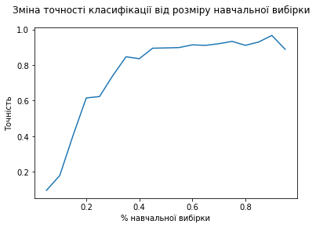

```python
plt.plot(Xaxes, res)
plt.suptitle('Зміна точності класифікації від розміру навчальної вибірки')
plt.xlabel('% навчальної вибірки')
plt.ylabel('Точність')
```

Очевидно, що на маленьких навчальних вибірках модель працює погано, але зі збільшенням вибірки вона дуже швидко покращує результати та стабілізується. Дослідимо лінійні моделі:

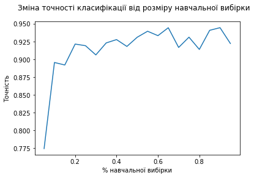

```python
res=[]
Xaxes=[]
for i in range (19):
    x_train, x_test, y_train, y_test = train_test_split(X, Y, test_size=(1-i/20-1/20))
    classifier=LinearSVC(C=0.0014767862575711605).fit(x_train, y_train)
    res.append(accuracy_score(y_test, classifier.predict(x_test)))
    Xaxes.append(i/20+1/20)
plt.plot(Xaxes, res)
plt.suptitle('Зміна точності класифікації від розміру навчальної вибірки')
plt.xlabel('% навчальної вибірки')
plt.ylabel('Точність')
```

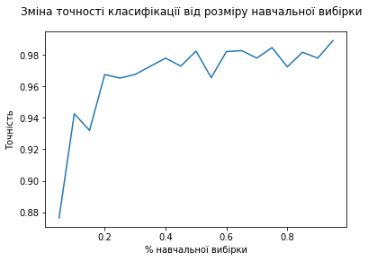

```python
res=[]
Xaxes=[]
for i in range (19):
    x_train, x_test, y_train, y_test = train_test_split(X, Y, test_size=(1-i/20-1/20))
    classifier=SVC(kernel='linear', C= 0.0445).fit(x_train, y_train)
    res.append(accuracy_score(y_test, classifier.predict(x_test)))
    Xaxes.append(i/20+1/20)
plt.plot(Xaxes, res)
plt.suptitle('Зміна точності класифікації від розміру навчальної вибірки')
plt.xlabel('% навчальної вибірки')
plt.ylabel('Точність')
```

Для обох моделей спостерігається швидке зростання точності при зростанні розміру вибірки в декілька разів, але точність швидко стабілізується та не змінюється

## Висновки

Найкраща модель з запропонованих для набору цифр - це метод опорних векторів з гаусівським радіальним ядром, яка навіть на дефолтних параметрах показує високу точність класифікації, але і інші моделі показують дуже високі результати